# Risk Factor Analysis

## Outcome Variable

**Outcome Variable:** ever_swasted

## Predictor Variables

**Intervention Variable:** parity

**Adjustment Set:**

unadjusted

## Stratifying Variables

The analysis was stratified on these variable(s):

- agecat
- studyid
- country

## Data Summary

| agecat | studyid | country | parity | ever_swasted | n_cell | n |
| --- | --- | --- | --- | --- | --- | --- |
| 0-24 months | ki1000304b-SAS-CompFeed | INDIA | 1 | 0 | 131 | 463 |
| 0-24 months | ki1000304b-SAS-CompFeed | INDIA | 1 | 1 | 11 | 463 |
| 0-24 months | ki1000304b-SAS-CompFeed | INDIA | 2 | 0 | 88 | 463 |
| 0-24 months | ki1000304b-SAS-CompFeed | INDIA | 2 | 1 | 17 | 463 |
| 0-24 months | ki1000304b-SAS-CompFeed | INDIA | 3+ | 0 | 178 | 463 |
| 0-24 months | ki1000304b-SAS-CompFeed | INDIA | 3+ | 1 | 38 | 463 |
| 0-24 months | ki1000304b-SAS-FoodSuppl | INDIA | 1 | 0 | 17 | 101 |
| 0-24 months | ki1000304b-SAS-FoodSuppl | INDIA | 1 | 1 | 2 | 101 |
| 0-24 months | ki1000304b-SAS-FoodSuppl | INDIA | 2 | 0 | 18 | 101 |
| 0-24 months | ki1000304b-SAS-FoodSuppl | INDIA | 2 | 1 | 3 | 101 |
| 0-24 months | ki1000304b-SAS-FoodSuppl | INDIA | 3+ | 0 | 47 | 101 |
| 0-24 months | ki1000304b-SAS-FoodSuppl | INDIA | 3+ | 1 | 14 | 101 |
| 0-24 months | ki1017093b-PROVIDE | BANGLADESH | 1 | 0 | 252 | 700 |
| 0-24 months | ki1017093b-PROVIDE | BANGLADESH | 1 | 1 | 19 | 700 |
| 0-24 months | ki1017093b-PROVIDE | BANGLADESH | 2 | 0 | 236 | 700 |
| 0-24 months | ki1017093b-PROVIDE | BANGLADESH | 2 | 1 | 8 | 700 |
| 0-24 months | ki1017093b-PROVIDE | BANGLADESH | 3+ | 0 | 170 | 700 |
| 0-24 months | ki1017093b-PROVIDE | BANGLADESH | 3+ | 1 | 15 | 700 |
| 0-24 months | ki1066203-TanzaniaChild2 | TANZANIA, UNITED REPUBLIC OF | 1 | 0 | 767 | 2357 |
| 0-24 months | ki1066203-TanzaniaChild2 | TANZANIA, UNITED REPUBLIC OF | 1 | 1 | 54 | 2357 |
| 0-24 months | ki1066203-TanzaniaChild2 | TANZANIA, UNITED REPUBLIC OF | 2 | 0 | 717 | 2357 |
| 0-24 months | ki1066203-TanzaniaChild2 | TANZANIA, UNITED REPUBLIC OF | 2 | 1 | 54 | 2357 |
| 0-24 months | ki1066203-TanzaniaChild2 | TANZANIA, UNITED REPUBLIC OF | 3+ | 0 | 716 | 2357 |
| 0-24 months | ki1066203-TanzaniaChild2 | TANZANIA, UNITED REPUBLIC OF | 3+ | 1 | 49 | 2357 |
| 0-24 months | ki1101329-Keneba | GAMBIA | 1 | 0 | 208 | 1989 |
| 0-24 months | ki1101329-Keneba | GAMBIA | 1 | 1 | 32 | 1989 |
| 0-24 months | ki1101329-Keneba | GAMBIA | 2 | 0 | 184 | 1989 |
| 0-24 months | ki1101329-Keneba | GAMBIA | 2 | 1 | 30 | 1989 |
| 0-24 months | ki1101329-Keneba | GAMBIA | 3+ | 0 | 1279 | 1989 |
| 0-24 months | ki1101329-Keneba | GAMBIA | 3+ | 1 | 256 | 1989 |

[output cut: 168 more lines]

The following strata were considered:

- agecat: 0-24 months, studyid: ki1000304b-SAS-CompFeed, country: INDIA
- agecat: 0-24 months, studyid: ki1000304b-SAS-FoodSuppl, country: INDIA
- agecat: 0-24 months, studyid: ki1017093b-PROVIDE, country: BANGLADESH
- agecat: 0-24 months, studyid: ki1066203-TanzaniaChild2, country: TANZANIA, UNITED REPUBLIC OF
- agecat: 0-24 months, studyid: ki1101329-Keneba, country: GAMBIA
- agecat: 0-24 months, studyid: ki1113344-GMS-Nepal, country: NEPAL
- agecat: 0-24 months, studyid: ki1126311-ZVITAMBO, country: ZIMBABWE
- agecat: 0-24 months, studyid: ki1135781-COHORTS, country: GUATEMALA
- agecat: 0-24 months, studyid: ki1135781-COHORTS, country: INDIA
- agecat: 0-24 months, studyid: ki1135781-COHORTS, country: PHILIPPINES
- agecat: 0-24 months, studyid: kiGH5241-JiVitA-3, country: BANGLADESH
- agecat: 0-6 months, studyid: ki1000304b-SAS-CompFeed, country: INDIA
- agecat: 0-6 months, studyid: ki1000304b-SAS-FoodSuppl, country: INDIA
- agecat: 0-6 months, studyid: ki1017093b-PROVIDE, country: BANGLADESH
- agecat: 0-6 months, studyid: ki1066203-TanzaniaChild2, country: TANZANIA, UNITED REPUBLIC OF
- agecat: 0-6 months, studyid: ki1101329-Keneba, country: GAMBIA
- agecat: 0-6 months, studyid: ki1113344-GMS-Nepal, country: NEPAL
- agecat: 0-6 months, studyid: ki1126311-ZVITAMBO, country: ZIMBABWE
- agecat: 0-6 months, studyid: ki1135781-COHORTS, country: GUATEMALA
- agecat: 0-6 months, studyid: ki1135781-COHORTS, country: INDIA
- agecat: 0-6 months, studyid: ki1135781-COHORTS, country: PHILIPPINES
- agecat: 0-6 months, studyid: kiGH5241-JiVitA-3, country: BANGLADESH
- agecat: 6-24 months, studyid: ki1000304b-SAS-CompFeed, country: INDIA
- agecat: 6-24 months, studyid: ki1000304b-SAS-FoodSuppl, country: INDIA
- agecat: 6-24 months, studyid: ki1017093b-PROVIDE, country: BANGLADESH
- agecat: 6-24 months, studyid: ki1066203-TanzaniaChild2, country: TANZANIA, UNITED REPUBLIC OF
- agecat: 6-24 months, studyid: ki1101329-Keneba, country: GAMBIA
- agecat: 6-24 months, studyid: ki1113344-GMS-Nepal, country: NEPAL
- agecat: 6-24 months, studyid: ki1126311-ZVITAMBO, country: ZIMBABWE
- agecat: 6-24 months, studyid: ki1135781-COHORTS, country: GUATEMALA
- agecat: 6-24 months, studyid: ki1135781-COHORTS, country: INDIA
- agecat: 6-24 months, studyid: ki1135781-COHORTS, country: PHILIPPINES
- agecat: 6-24 months, studyid: kiGH5241-JiVitA-3, country: BANGLADESH

### Dropped Strata

Some strata were dropped due to rare outcomes:

- agecat: 0-24 months, studyid: ki1000304b-SAS-FoodSuppl, country: INDIA
- agecat: 0-6 months, studyid: ki1000304b-SAS-CompFeed, country: INDIA
- agecat: 0-6 months, studyid: ki1000304b-SAS-FoodSuppl, country: INDIA
- agecat: 0-6 months, studyid: ki1017093b-PROVIDE, country: BANGLADESH
- agecat: 6-24 months, studyid: ki1000304b-SAS-FoodSuppl, country: INDIA
- agecat: 6-24 months, studyid: ki1017093b-PROVIDE, country: BANGLADESH
- agecat: 6-24 months, studyid: ki1135781-COHORTS, country: GUATEMALA

## Methods Detail

We’re interested in the causal parameters $E[Y_a]$ for all values of $a \in \mathcal{A}$. These parameters represent the mean outcome if, possibly contrary to fact, we intervened to set all units to have $A=a$. Under the randomization and positivity assumptions, these are identified by the statistical parameters $\psi_a=E_W[E_{Y|A,W}(Y|A=a,W)]$. In addition, we’re interested in the mean of $Y$, $E[Y]$ under no intervention (the observed mean). We will estimate these parameters by using SuperLearner to fit the relevant likelihood factors – $E_{Y|A,W}(Y|A=a,W)$ and $p(A=a|W)$, and then updating our likelihood fit using a joint TMLE.

For unadjusted analyses ($W=\{\}$), initial likelihoods were estimated using Lrnr_glm to estimate the simple $E(Y|A)$ and Lrnr_mean to estimate $p(A)$. For adjusted analyses, a small library containing Lrnr_glmnet, Lrnr_xgboost, and Lrnr_mean was used.

Having estimated these parameters, we will then use the delta method to estimate relative risks and attributable risks relative to a prespecified baseline level of $A$.

# Results Detail

## Results Plots

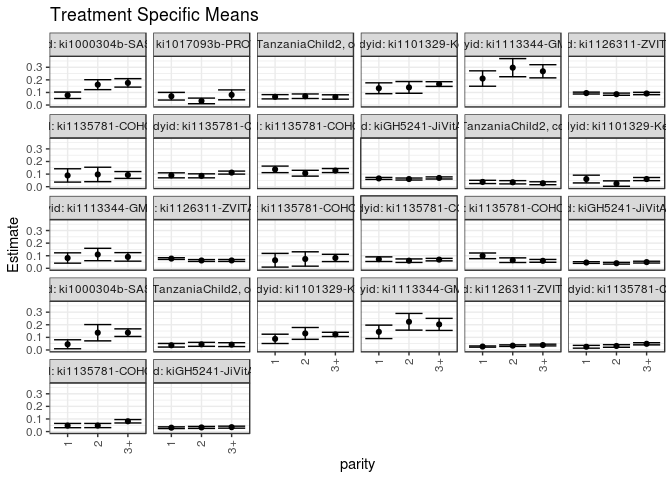

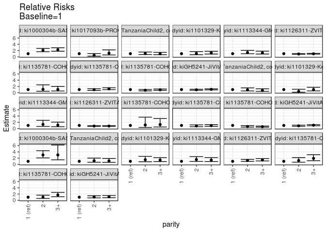

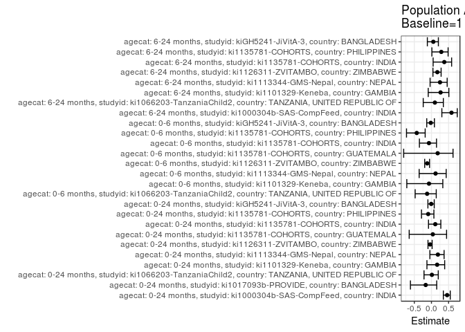

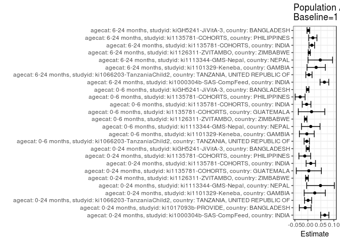

## Results Table

### Parameter: TSM

| agecat | studyid | country | intervention_level | baseline_level | estimate | ci_lower | ci_upper |
| --- | --- | --- | --- | --- | --- | --- | --- |
| 0-24 months | ki1000304b-SAS-CompFeed | INDIA | 1 | NA | 0.0774648 | 0.0518696 | 0.1030600 |
| 0-24 months | ki1000304b-SAS-CompFeed | INDIA | 2 | NA | 0.1619048 | 0.1224675 | 0.2013420 |
| 0-24 months | ki1000304b-SAS-CompFeed | INDIA | 3+ | NA | 0.1759259 | 0.1423685 | 0.2094833 |
| 0-24 months | ki1017093b-PROVIDE | BANGLADESH | 1 | NA | 0.0701107 | 0.0396891 | 0.1005323 |
| 0-24 months | ki1017093b-PROVIDE | BANGLADESH | 2 | NA | 0.0327869 | 0.0104267 | 0.0551470 |
| 0-24 months | ki1017093b-PROVIDE | BANGLADESH | 3+ | NA | 0.0810811 | 0.0417196 | 0.1204425 |
| 0-24 months | ki1066203-TanzaniaChild2 | TANZANIA, UNITED REPUBLIC OF | 1 | NA | 0.0657734 | 0.0488137 | 0.0827332 |
| 0-24 months | ki1066203-TanzaniaChild2 | TANZANIA, UNITED REPUBLIC OF | 2 | NA | 0.0700389 | 0.0520206 | 0.0880573 |
| 0-24 months | ki1066203-TanzaniaChild2 | TANZANIA, UNITED REPUBLIC OF | 3+ | NA | 0.0640523 | 0.0466982 | 0.0814064 |
| 0-24 months | ki1101329-Keneba | GAMBIA | 1 | NA | 0.1333333 | 0.0903156 | 0.1763510 |
| 0-24 months | ki1101329-Keneba | GAMBIA | 2 | NA | 0.1401869 | 0.0936598 | 0.1867140 |
| 0-24 months | ki1101329-Keneba | GAMBIA | 3+ | NA | 0.1667752 | 0.1481222 | 0.1854283 |
| 0-24 months | ki1113344-GMS-Nepal | NEPAL | 1 | NA | 0.2105263 | 0.1493712 | 0.2716815 |
| 0-24 months | ki1113344-GMS-Nepal | NEPAL | 2 | NA | 0.2967742 | 0.2247955 | 0.3687528 |
| 0-24 months | ki1113344-GMS-Nepal | NEPAL | 3+ | NA | 0.2681159 | 0.2158117 | 0.3204202 |
| 0-24 months | ki1126311-ZVITAMBO | ZIMBABWE | 1 | NA | 0.0951191 | 0.0876973 | 0.1025409 |
| 0-24 months | ki1126311-ZVITAMBO | ZIMBABWE | 2 | NA | 0.0862275 | 0.0777127 | 0.0947424 |
| 0-24 months | ki1126311-ZVITAMBO | ZIMBABWE | 3+ | NA | 0.0917553 | 0.0825278 | 0.1009829 |
| 0-24 months | ki1135781-COHORTS | GUATEMALA | 1 | NA | 0.0892857 | 0.0364348 | 0.1421366 |
| 0-24 months | ki1135781-COHORTS | GUATEMALA | 2 | NA | 0.0970874 | 0.0398651 | 0.1543096 |
| 0-24 months | ki1135781-COHORTS | GUATEMALA | 3+ | NA | 0.0929705 | 0.0658472 | 0.1200939 |
| 0-24 months | ki1135781-COHORTS | INDIA | 1 | NA | 0.0901235 | 0.0704009 | 0.1098460 |
| 0-24 months | ki1135781-COHORTS | INDIA | 2 | NA | 0.0861486 | 0.0701648 | 0.1021325 |
| 0-24 months | ki1135781-COHORTS | INDIA | 3+ | NA | 0.1117871 | 0.0997431 | 0.1238311 |
| 0-24 months | ki1135781-COHORTS | PHILIPPINES | 1 | NA | 0.1373708 | 0.1114359 | 0.1633056 |
| 0-24 months | ki1135781-COHORTS | PHILIPPINES | 2 | NA | 0.1070381 | 0.0838314 | 0.1302448 |
| 0-24 months | ki1135781-COHORTS | PHILIPPINES | 3+ | NA | 0.1281139 | 0.1121581 | 0.1440697 |
| 0-24 months | kiGH5241-JiVitA-3 | BANGLADESH | 1 | NA | 0.0655117 | 0.0576021 | 0.0734214 |
| 0-24 months | kiGH5241-JiVitA-3 | BANGLADESH | 2 | NA | 0.0607424 | 0.0527944 | 0.0686904 |
| 0-24 months | kiGH5241-JiVitA-3 | BANGLADESH | 3+ | NA | 0.0694228 | 0.0610393 | 0.0778063 |
| 0-6 months | ki1066203-TanzaniaChild2 | TANZANIA, UNITED REPUBLIC OF | 1 | NA | 0.0377588 | 0.0247176 | 0.0508001 |
| 0-6 months | ki1066203-TanzaniaChild2 | TANZANIA, UNITED REPUBLIC OF | 2 | NA | 0.0350195 | 0.0220409 | 0.0479980 |
| 0-6 months | ki1066203-TanzaniaChild2 | TANZANIA, UNITED REPUBLIC OF | 3+ | NA | 0.0274510 | 0.0158700 | 0.0390319 |
| 0-6 months | ki1101329-Keneba | GAMBIA | 1 | NA | 0.0606061 | 0.0298279 | 0.0913843 |
| 0-6 months | ki1101329-Keneba | GAMBIA | 2 | NA | 0.0247525 | 0.0033207 | 0.0461843 |
| 0-6 months | ki1101329-Keneba | GAMBIA | 3+ | NA | 0.0604752 | 0.0479363 | 0.0730140 |
| 0-6 months | ki1113344-GMS-Nepal | NEPAL | 1 | NA | 0.0818713 | 0.0407442 | 0.1229985 |
| 0-6 months | ki1113344-GMS-Nepal | NEPAL | 2 | NA | 0.1096774 | 0.0604422 | 0.1589126 |
| 0-6 months | ki1113344-GMS-Nepal | NEPAL | 3+ | NA | 0.0905797 | 0.0566912 | 0.1244682 |
| 0-6 months | ki1126311-ZVITAMBO | ZIMBABWE | 1 | NA | 0.0772071 | 0.0704292 | 0.0839850 |
| 0-6 months | ki1126311-ZVITAMBO | ZIMBABWE | 2 | NA | 0.0621387 | 0.0547955 | 0.0694819 |
| 0-6 months | ki1126311-ZVITAMBO | ZIMBABWE | 3+ | NA | 0.0623662 | 0.0546117 | 0.0701206 |
| 0-6 months | ki1135781-COHORTS | GUATEMALA | 1 | NA | 0.0641026 | 0.0096927 | 0.1185125 |
| 0-6 months | ki1135781-COHORTS | GUATEMALA | 2 | NA | 0.0740741 | 0.0169851 | 0.1311630 |
| 0-6 months | ki1135781-COHORTS | GUATEMALA | 3+ | NA | 0.0823864 | 0.0536349 | 0.1111378 |
| 0-6 months | ki1135781-COHORTS | INDIA | 1 | NA | 0.0724638 | 0.0540178 | 0.0909098 |
| 0-6 months | ki1135781-COHORTS | INDIA | 2 | NA | 0.0606860 | 0.0468068 | 0.0745653 |
| 0-6 months | ki1135781-COHORTS | INDIA | 3+ | NA | 0.0690738 | 0.0592266 | 0.0789210 |
| 0-6 months | ki1135781-COHORTS | PHILIPPINES | 1 | NA | 0.0991124 | 0.0765832 | 0.1216416 |
| 0-6 months | ki1135781-COHORTS | PHILIPPINES | 2 | NA | 0.0645161 | 0.0460753 | 0.0829569 |
| 0-6 months | ki1135781-COHORTS | PHILIPPINES | 3+ | NA | 0.0593120 | 0.0480352 | 0.0705887 |
| 0-6 months | kiGH5241-JiVitA-3 | BANGLADESH | 1 | NA | 0.0459010 | 0.0393690 | 0.0524330 |
| 0-6 months | kiGH5241-JiVitA-3 | BANGLADESH | 2 | NA | 0.0403517 | 0.0334968 | 0.0472066 |
| 0-6 months | kiGH5241-JiVitA-3 | BANGLADESH | 3+ | NA | 0.0492316 | 0.0421114 | 0.0563518 |
| 6-24 months | ki1000304b-SAS-CompFeed | INDIA | 1 | NA | 0.0451128 | 0.0092896 | 0.0809359 |
| 6-24 months | ki1000304b-SAS-CompFeed | INDIA | 2 | NA | 0.1368421 | 0.0720837 | 0.2016006 |
| 6-24 months | ki1000304b-SAS-CompFeed | INDIA | 3+ | NA | 0.1372549 | 0.1070815 | 0.1674283 |
| 6-24 months | ki1066203-TanzaniaChild2 | TANZANIA, UNITED REPUBLIC OF | 1 | NA | 0.0371471 | 0.0228551 | 0.0514391 |
| 6-24 months | ki1066203-TanzaniaChild2 | TANZANIA, UNITED REPUBLIC OF | 2 | NA | 0.0444785 | 0.0286504 | 0.0603066 |
| 6-24 months | ki1066203-TanzaniaChild2 | TANZANIA, UNITED REPUBLIC OF | 3+ | NA | 0.0422961 | 0.0269607 | 0.0576314 |
| 6-24 months | ki1101329-Keneba | GAMBIA | 1 | NA | 0.0881057 | 0.0512231 | 0.1249884 |
| 6-24 months | ki1101329-Keneba | GAMBIA | 2 | NA | 0.1313131 | 0.0842572 | 0.1783690 |
| 6-24 months | ki1101329-Keneba | GAMBIA | 3+ | NA | 0.1234156 | 0.1067607 | 0.1400705 |
| 6-24 months | ki1113344-GMS-Nepal | NEPAL | 1 | NA | 0.1437126 | 0.0904631 | 0.1969621 |
| 6-24 months | ki1113344-GMS-Nepal | NEPAL | 2 | NA | 0.2236842 | 0.1573815 | 0.2899870 |
| 6-24 months | ki1113344-GMS-Nepal | NEPAL | 3+ | NA | 0.2029520 | 0.1550261 | 0.2508780 |
| 6-24 months | ki1126311-ZVITAMBO | ZIMBABWE | 1 | NA | 0.0269719 | 0.0221914 | 0.0317523 |
| 6-24 months | ki1126311-ZVITAMBO | ZIMBABWE | 2 | NA | 0.0341328 | 0.0278921 | 0.0403736 |
| 6-24 months | ki1126311-ZVITAMBO | ZIMBABWE | 3+ | NA | 0.0389568 | 0.0320658 | 0.0458477 |
| 6-24 months | ki1135781-COHORTS | INDIA | 1 | NA | 0.0252324 | 0.0140295 | 0.0364353 |
| 6-24 months | ki1135781-COHORTS | INDIA | 2 | NA | 0.0316742 | 0.0213471 | 0.0420014 |
| 6-24 months | ki1135781-COHORTS | INDIA | 3+ | NA | 0.0487707 | 0.0402943 | 0.0572470 |
| 6-24 months | ki1135781-COHORTS | PHILIPPINES | 1 | NA | 0.0476974 | 0.0307537 | 0.0646411 |
| 6-24 months | ki1135781-COHORTS | PHILIPPINES | 2 | NA | 0.0480000 | 0.0312381 | 0.0647619 |
| 6-24 months | ki1135781-COHORTS | PHILIPPINES | 3+ | NA | 0.0818528 | 0.0683159 | 0.0953897 |
| 6-24 months | kiGH5241-JiVitA-3 | BANGLADESH | 1 | NA | 0.0309681 | 0.0242780 | 0.0376582 |
| 6-24 months | kiGH5241-JiVitA-3 | BANGLADESH | 2 | NA | 0.0329518 | 0.0252900 | 0.0406136 |
| 6-24 months | kiGH5241-JiVitA-3 | BANGLADESH | 3+ | NA | 0.0350427 | 0.0271630 | 0.0429225 |

### Parameter: E(Y)

| agecat | studyid | country | intervention_level | baseline_level | estimate | ci_lower | ci_upper |
| --- | --- | --- | --- | --- | --- | --- | --- |
| 0-24 months | ki1000304b-SAS-CompFeed | INDIA | NA | NA | 0.1425486 | 0.1120439 | 0.1730533 |
| 0-24 months | ki1017093b-PROVIDE | BANGLADESH | NA | NA | 0.0600000 | 0.0423945 | 0.0776055 |
| 0-24 months | ki1066203-TanzaniaChild2 | TANZANIA, UNITED REPUBLIC OF | NA | NA | 0.0666101 | 0.0565417 | 0.0766785 |
| 0-24 months | ki1101329-Keneba | GAMBIA | NA | NA | 0.1598793 | 0.1437689 | 0.1759898 |
| 0-24 months | ki1113344-GMS-Nepal | NEPAL | NA | NA | 0.2591362 | 0.2241059 | 0.2941665 |
| 0-24 months | ki1126311-ZVITAMBO | ZIMBABWE | NA | NA | 0.0915483 | 0.0867604 | 0.0963361 |
| 0-24 months | ki1135781-COHORTS | GUATEMALA | NA | NA | 0.0929878 | 0.0707472 | 0.1152284 |
| 0-24 months | ki1135781-COHORTS | INDIA | NA | NA | 0.1014273 | 0.0927249 | 0.1101298 |
| 0-24 months | ki1135781-COHORTS | PHILIPPINES | NA | NA | 0.1254516 | 0.1136848 | 0.1372183 |
| 0-24 months | kiGH5241-JiVitA-3 | BANGLADESH | NA | NA | 0.0650492 | 0.0602046 | 0.0698938 |
| 0-6 months | ki1066203-TanzaniaChild2 | TANZANIA, UNITED REPUBLIC OF | NA | NA | 0.0335172 | 0.0262496 | 0.0407848 |
| 0-6 months | ki1101329-Keneba | GAMBIA | NA | NA | 0.0565313 | 0.0459241 | 0.0671385 |
| 0-6 months | ki1113344-GMS-Nepal | NEPAL | NA | NA | 0.0930233 | 0.0698010 | 0.1162455 |
| 0-6 months | ki1126311-ZVITAMBO | ZIMBABWE | NA | NA | 0.0686841 | 0.0644712 | 0.0728970 |
| 0-6 months | ki1135781-COHORTS | GUATEMALA | NA | NA | 0.0782779 | 0.0549657 | 0.1015900 |
| 0-6 months | ki1135781-COHORTS | INDIA | NA | NA | 0.0675068 | 0.0601293 | 0.0748842 |
| 0-6 months | ki1135781-COHORTS | PHILIPPINES | NA | NA | 0.0693167 | 0.0602923 | 0.0783411 |
| 0-6 months | kiGH5241-JiVitA-3 | BANGLADESH | NA | NA | 0.0450090 | 0.0407907 | 0.0492274 |
| 6-24 months | ki1000304b-SAS-CompFeed | INDIA | NA | NA | 0.1087963 | 0.0724447 | 0.1451479 |
| 6-24 months | ki1066203-TanzaniaChild2 | TANZANIA, UNITED REPUBLIC OF | NA | NA | 0.0412682 | 0.0325201 | 0.0500164 |
| 6-24 months | ki1101329-Keneba | GAMBIA | NA | NA | 0.1200624 | 0.1055350 | 0.1345898 |
| 6-24 months | ki1113344-GMS-Nepal | NEPAL | NA | NA | 0.1915254 | 0.1597467 | 0.2233042 |
| 6-24 months | ki1126311-ZVITAMBO | ZIMBABWE | NA | NA | 0.0325447 | 0.0291813 | 0.0359080 |
| 6-24 months | ki1135781-COHORTS | INDIA | NA | NA | 0.0403319 | 0.0344774 | 0.0461863 |
| 6-24 months | ki1135781-COHORTS | PHILIPPINES | NA | NA | 0.0669277 | 0.0576848 | 0.0761707 |
| 6-24 months | kiGH5241-JiVitA-3 | BANGLADESH | NA | NA | 0.0327524 | 0.0284767 | 0.0370280 |

### Parameter: RR

| agecat | studyid | country | intervention_level | baseline_level | estimate | ci_lower | ci_upper |
| --- | --- | --- | --- | --- | --- | --- | --- |
| 0-24 months | ki1000304b-SAS-CompFeed | INDIA | 1 | 1 | 1.0000000 | 1.0000000 | 1.0000000 |
| 0-24 months | ki1000304b-SAS-CompFeed | INDIA | 2 | 1 | 2.0900433 | 1.6347837 | 2.6720850 |
| 0-24 months | ki1000304b-SAS-CompFeed | INDIA | 3+ | 1 | 2.2710438 | 1.7819953 | 2.8943060 |
| 0-24 months | ki1017093b-PROVIDE | BANGLADESH | 1 | 1 | 1.0000000 | 1.0000000 | 1.0000000 |
| 0-24 months | ki1017093b-PROVIDE | BANGLADESH | 2 | 1 | 0.4676445 | 0.2083855 | 1.0494558 |
| 0-24 months | ki1017093b-PROVIDE | BANGLADESH | 3+ | 1 | 1.1564723 | 0.6030613 | 2.2177317 |
| 0-24 months | ki1066203-TanzaniaChild2 | TANZANIA, UNITED REPUBLIC OF | 1 | 1 | 1.0000000 | 1.0000000 | 1.0000000 |
| 0-24 months | ki1066203-TanzaniaChild2 | TANZANIA, UNITED REPUBLIC OF | 2 | 1 | 1.0648508 | 0.7397776 | 1.5327679 |
| 0-24 months | ki1066203-TanzaniaChild2 | TANZANIA, UNITED REPUBLIC OF | 3+ | 1 | 0.9738320 | 0.6699577 | 1.4155352 |
| 0-24 months | ki1101329-Keneba | GAMBIA | 1 | 1 | 1.0000000 | 1.0000000 | 1.0000000 |
| 0-24 months | ki1101329-Keneba | GAMBIA | 2 | 1 | 1.0514019 | 0.6618331 | 1.6702788 |
| 0-24 months | ki1101329-Keneba | GAMBIA | 3+ | 1 | 1.2508143 | 0.8889854 | 1.7599124 |
| 0-24 months | ki1113344-GMS-Nepal | NEPAL | 1 | 1 | 1.0000000 | 1.0000000 | 1.0000000 |
| 0-24 months | ki1113344-GMS-Nepal | NEPAL | 2 | 1 | 1.4096774 | 0.9655419 | 2.0581090 |
| 0-24 months | ki1113344-GMS-Nepal | NEPAL | 3+ | 1 | 1.2735507 | 0.8975340 | 1.8070975 |
| 0-24 months | ki1126311-ZVITAMBO | ZIMBABWE | 1 | 1 | 1.0000000 | 1.0000000 | 1.0000000 |
| 0-24 months | ki1126311-ZVITAMBO | ZIMBABWE | 2 | 1 | 0.9065218 | 0.7993192 | 1.0281022 |
| 0-24 months | ki1126311-ZVITAMBO | ZIMBABWE | 3+ | 1 | 0.9646360 | 0.8493441 | 1.0955779 |
| 0-24 months | ki1135781-COHORTS | GUATEMALA | 1 | 1 | 1.0000000 | 1.0000000 | 1.0000000 |
| 0-24 months | ki1135781-COHORTS | GUATEMALA | 2 | 1 | 1.0873786 | 0.4716345 | 2.5070099 |
| 0-24 months | ki1135781-COHORTS | GUATEMALA | 3+ | 1 | 1.0412698 | 0.5382248 | 2.0144796 |
| 0-24 months | ki1135781-COHORTS | INDIA | 1 | 1 | 1.0000000 | 1.0000000 | 1.0000000 |
| 0-24 months | ki1135781-COHORTS | INDIA | 2 | 1 | 0.9558960 | 0.7174788 | 1.2735388 |
| 0-24 months | ki1135781-COHORTS | INDIA | 3+ | 1 | 1.2403771 | 0.9718946 | 1.5830270 |
| 0-24 months | ki1135781-COHORTS | PHILIPPINES | 1 | 1 | 1.0000000 | 1.0000000 | 1.0000000 |
| 0-24 months | ki1135781-COHORTS | PHILIPPINES | 2 | 1 | 0.7791915 | 0.5845074 | 1.0387198 |
| 0-24 months | ki1135781-COHORTS | PHILIPPINES | 3+ | 1 | 0.9326139 | 0.7438336 | 1.1693055 |
| 0-24 months | kiGH5241-JiVitA-3 | BANGLADESH | 1 | 1 | 1.0000000 | 1.0000000 | 1.0000000 |
| 0-24 months | kiGH5241-JiVitA-3 | BANGLADESH | 2 | 1 | 0.9271987 | 0.7732070 | 1.1118593 |
| 0-24 months | kiGH5241-JiVitA-3 | BANGLADESH | 3+ | 1 | 1.0596997 | 0.9024929 | 1.2442905 |
| 0-6 months | ki1066203-TanzaniaChild2 | TANZANIA, UNITED REPUBLIC OF | 1 | 1 | 1.0000000 | 1.0000000 | 1.0000000 |
| 0-6 months | ki1066203-TanzaniaChild2 | TANZANIA, UNITED REPUBLIC OF | 2 | 1 | 0.9274507 | 0.5588279 | 1.5392305 |
| 0-6 months | ki1066203-TanzaniaChild2 | TANZANIA, UNITED REPUBLIC OF | 3+ | 1 | 0.7270082 | 0.4214549 | 1.2540865 |
| 0-6 months | ki1101329-Keneba | GAMBIA | 1 | 1 | 1.0000000 | 1.0000000 | 1.0000000 |
| 0-6 months | ki1101329-Keneba | GAMBIA | 2 | 1 | 0.4084158 | 0.1496799 | 1.1144014 |
| 0-6 months | ki1101329-Keneba | GAMBIA | 3+ | 1 | 0.9978402 | 0.5765473 | 1.7269788 |
| 0-6 months | ki1113344-GMS-Nepal | NEPAL | 1 | 1 | 1.0000000 | 1.0000000 | 1.0000000 |
| 0-6 months | ki1113344-GMS-Nepal | NEPAL | 2 | 1 | 1.3396313 | 0.6829732 | 2.6276464 |
| 0-6 months | ki1113344-GMS-Nepal | NEPAL | 3+ | 1 | 1.1063665 | 0.5913951 | 2.0697613 |
| 0-6 months | ki1126311-ZVITAMBO | ZIMBABWE | 1 | 1 | 1.0000000 | 1.0000000 | 1.0000000 |
| 0-6 months | ki1126311-ZVITAMBO | ZIMBABWE | 2 | 1 | 0.8048316 | 0.6946576 | 0.9324795 |
| 0-6 months | ki1126311-ZVITAMBO | ZIMBABWE | 3+ | 1 | 0.8077774 | 0.6937285 | 0.9405760 |
| 0-6 months | ki1135781-COHORTS | GUATEMALA | 1 | 1 | 1.0000000 | 1.0000000 | 1.0000000 |
| 0-6 months | ki1135781-COHORTS | GUATEMALA | 2 | 1 | 1.1555556 | 0.3671790 | 3.6366690 |
| 0-6 months | ki1135781-COHORTS | GUATEMALA | 3+ | 1 | 1.2852273 | 0.5133479 | 3.2177188 |
| 0-6 months | ki1135781-COHORTS | INDIA | 1 | 1 | 1.0000000 | 1.0000000 | 1.0000000 |
| 0-6 months | ki1135781-COHORTS | INDIA | 2 | 1 | 0.8374670 | 0.5947710 | 1.1791951 |
| 0-6 months | ki1135781-COHORTS | INDIA | 3+ | 1 | 0.9532182 | 0.7120072 | 1.2761458 |
| 0-6 months | ki1135781-COHORTS | PHILIPPINES | 1 | 1 | 1.0000000 | 1.0000000 | 1.0000000 |
| 0-6 months | ki1135781-COHORTS | PHILIPPINES | 2 | 1 | 0.6509389 | 0.4517901 | 0.9378723 |
| 0-6 months | ki1135781-COHORTS | PHILIPPINES | 3+ | 1 | 0.5984313 | 0.4449543 | 0.8048469 |
| 0-6 months | kiGH5241-JiVitA-3 | BANGLADESH | 1 | 1 | 1.0000000 | 1.0000000 | 1.0000000 |
| 0-6 months | kiGH5241-JiVitA-3 | BANGLADESH | 2 | 1 | 0.8791025 | 0.7037188 | 1.0981961 |
| 0-6 months | kiGH5241-JiVitA-3 | BANGLADESH | 3+ | 1 | 1.0725603 | 0.8874486 | 1.2962841 |
| 6-24 months | ki1000304b-SAS-CompFeed | INDIA | 1 | 1 | 1.0000000 | 1.0000000 | 1.0000000 |
| 6-24 months | ki1000304b-SAS-CompFeed | INDIA | 2 | 1 | 3.0333332 | 2.0941993 | 4.3936175 |
| 6-24 months | ki1000304b-SAS-CompFeed | INDIA | 3+ | 1 | 3.0424836 | 1.4889076 | 6.2171125 |
| 6-24 months | ki1066203-TanzaniaChild2 | TANZANIA, UNITED REPUBLIC OF | 1 | 1 | 1.0000000 | 1.0000000 | 1.0000000 |
| 6-24 months | ki1066203-TanzaniaChild2 | TANZANIA, UNITED REPUBLIC OF | 2 | 1 | 1.1973620 | 0.7089571 | 2.0222319 |
| 6-24 months | ki1066203-TanzaniaChild2 | TANZANIA, UNITED REPUBLIC OF | 3+ | 1 | 1.1386103 | 0.6710892 | 1.9318347 |
| 6-24 months | ki1101329-Keneba | GAMBIA | 1 | 1 | 1.0000000 | 1.0000000 | 1.0000000 |
| 6-24 months | ki1101329-Keneba | GAMBIA | 2 | 1 | 1.4904038 | 0.8589866 | 2.5859584 |
| 6-24 months | ki1101329-Keneba | GAMBIA | 3+ | 1 | 1.4007670 | 0.9022960 | 2.1746168 |
| 6-24 months | ki1113344-GMS-Nepal | NEPAL | 1 | 1 | 1.0000000 | 1.0000000 | 1.0000000 |
| 6-24 months | ki1113344-GMS-Nepal | NEPAL | 2 | 1 | 1.5564693 | 0.9684283 | 2.5015755 |
| 6-24 months | ki1113344-GMS-Nepal | NEPAL | 3+ | 1 | 1.4122079 | 0.9100773 | 2.1913864 |
| 6-24 months | ki1126311-ZVITAMBO | ZIMBABWE | 1 | 1 | 1.0000000 | 1.0000000 | 1.0000000 |
| 6-24 months | ki1126311-ZVITAMBO | ZIMBABWE | 2 | 1 | 1.2654966 | 0.9810044 | 1.6324918 |
| 6-24 months | ki1126311-ZVITAMBO | ZIMBABWE | 3+ | 1 | 1.4443461 | 1.1244020 | 1.8553291 |
| 6-24 months | ki1135781-COHORTS | INDIA | 1 | 1 | 1.0000000 | 1.0000000 | 1.0000000 |
| 6-24 months | ki1135781-COHORTS | INDIA | 2 | 1 | 1.2552989 | 0.7236329 | 2.1775894 |
| 6-24 months | ki1135781-COHORTS | INDIA | 3+ | 1 | 1.9328581 | 1.1998616 | 3.1136430 |
| 6-24 months | ki1135781-COHORTS | PHILIPPINES | 1 | 1 | 1.0000000 | 1.0000000 | 1.0000000 |
| 6-24 months | ki1135781-COHORTS | PHILIPPINES | 2 | 1 | 1.0063448 | 0.6115196 | 1.6560874 |
| 6-24 months | ki1135781-COHORTS | PHILIPPINES | 3+ | 1 | 1.7160861 | 1.1597472 | 2.5393048 |
| 6-24 months | kiGH5241-JiVitA-3 | BANGLADESH | 1 | 1 | 1.0000000 | 1.0000000 | 1.0000000 |
| 6-24 months | kiGH5241-JiVitA-3 | BANGLADESH | 2 | 1 | 1.0640548 | 0.7747120 | 1.4614626 |
| 6-24 months | kiGH5241-JiVitA-3 | BANGLADESH | 3+ | 1 | 1.1315741 | 0.8318493 | 1.5392934 |

### Parameter: PAR

| agecat | studyid | country | intervention_level | baseline_level | estimate | ci_lower | ci_upper |
| --- | --- | --- | --- | --- | --- | --- | --- |
| 0-24 months | ki1000304b-SAS-CompFeed | INDIA | 1 | NA | 0.0650838 | 0.0492573 | 0.0809103 |
| 0-24 months | ki1017093b-PROVIDE | BANGLADESH | 1 | NA | -0.0101107 | -0.0328889 | 0.0126675 |
| 0-24 months | ki1066203-TanzaniaChild2 | TANZANIA, UNITED REPUBLIC OF | 1 | NA | 0.0008367 | -0.0128975 | 0.0145708 |
| 0-24 months | ki1101329-Keneba | GAMBIA | 1 | NA | 0.0265460 | -0.0142399 | 0.0673319 |
| 0-24 months | ki1113344-GMS-Nepal | NEPAL | 1 | NA | 0.0486099 | -0.0047041 | 0.1019239 |
| 0-24 months | ki1126311-ZVITAMBO | ZIMBABWE | 1 | NA | -0.0035708 | -0.0090988 | 0.0019572 |
| 0-24 months | ki1135781-COHORTS | GUATEMALA | 1 | NA | 0.0037021 | -0.0446102 | 0.0520144 |
| 0-24 months | ki1135781-COHORTS | INDIA | 1 | NA | 0.0113039 | -0.0068189 | 0.0294266 |
| 0-24 months | ki1135781-COHORTS | PHILIPPINES | 1 | NA | -0.0119192 | -0.0345463 | 0.0107079 |
| 0-24 months | kiGH5241-JiVitA-3 | BANGLADESH | 1 | NA | -0.0004625 | -0.0064646 | 0.0055395 |
| 0-6 months | ki1066203-TanzaniaChild2 | TANZANIA, UNITED REPUBLIC OF | 1 | NA | -0.0042416 | -0.0144598 | 0.0059765 |
| 0-6 months | ki1101329-Keneba | GAMBIA | 1 | NA | -0.0040748 | -0.0327035 | 0.0245540 |
| 0-6 months | ki1113344-GMS-Nepal | NEPAL | 1 | NA | 0.0111519 | -0.0244823 | 0.0467861 |
| 0-6 months | ki1126311-ZVITAMBO | ZIMBABWE | 1 | NA | -0.0085230 | -0.0134375 | -0.0036086 |
| 0-6 months | ki1135781-COHORTS | GUATEMALA | 1 | NA | 0.0141753 | -0.0368161 | 0.0651667 |
| 0-6 months | ki1135781-COHORTS | INDIA | 1 | NA | -0.0049570 | -0.0216440 | 0.0117300 |
| 0-6 months | ki1135781-COHORTS | PHILIPPINES | 1 | NA | -0.0297957 | -0.0488632 | -0.0107283 |
| 0-6 months | kiGH5241-JiVitA-3 | BANGLADESH | 1 | NA | -0.0008919 | -0.0059072 | 0.0041233 |
| 6-24 months | ki1000304b-SAS-CompFeed | INDIA | 1 | NA | 0.0636835 | 0.0469086 | 0.0804584 |
| 6-24 months | ki1066203-TanzaniaChild2 | TANZANIA, UNITED REPUBLIC OF | 1 | NA | 0.0041211 | -0.0078130 | 0.0160553 |
| 6-24 months | ki1101329-Keneba | GAMBIA | 1 | NA | 0.0319566 | -0.0034041 | 0.0673174 |
| 6-24 months | ki1113344-GMS-Nepal | NEPAL | 1 | NA | 0.0478128 | 0.0004820 | 0.0951437 |
| 6-24 months | ki1126311-ZVITAMBO | ZIMBABWE | 1 | NA | 0.0055728 | 0.0016604 | 0.0094851 |
| 6-24 months | ki1135781-COHORTS | INDIA | 1 | NA | 0.0150995 | 0.0043190 | 0.0258800 |
| 6-24 months | ki1135781-COHORTS | PHILIPPINES | 1 | NA | 0.0192304 | 0.0034747 | 0.0349861 |
| 6-24 months | kiGH5241-JiVitA-3 | BANGLADESH | 1 | NA | 0.0017842 | -0.0034569 | 0.0070254 |

### Parameter: PAF

| agecat | studyid | country | intervention_level | baseline_level | estimate | ci_lower | ci_upper |
| --- | --- | --- | --- | --- | --- | --- | --- |
| 0-24 months | ki1000304b-SAS-CompFeed | INDIA | 1 | NA | 0.4565728 | 0.3464429 | 0.5481448 |
| 0-24 months | ki1017093b-PROVIDE | BANGLADESH | 1 | NA | -0.1685117 | -0.6132761 | 0.1536356 |
| 0-24 months | ki1066203-TanzaniaChild2 | TANZANIA, UNITED REPUBLIC OF | 1 | NA | 0.0125604 | -0.2167250 | 0.1986382 |
| 0-24 months | ki1101329-Keneba | GAMBIA | 1 | NA | 0.1660377 | -0.1318771 | 0.3855401 |
| 0-24 months | ki1113344-GMS-Nepal | NEPAL | 1 | NA | 0.1875843 | -0.0456793 | 0.3688130 |
| 0-24 months | ki1126311-ZVITAMBO | ZIMBABWE | 1 | NA | -0.0390048 | -0.1011484 | 0.0196317 |
| 0-24 months | ki1135781-COHORTS | GUATEMALA | 1 | NA | 0.0398126 | -0.6493781 | 0.4410258 |
| 0-24 months | ki1135781-COHORTS | INDIA | 1 | NA | 0.1114481 | -0.0862109 | 0.2731388 |
| 0-24 months | ki1135781-COHORTS | PHILIPPINES | 1 | NA | -0.0950103 | -0.2909022 | 0.0711554 |
| 0-24 months | kiGH5241-JiVitA-3 | BANGLADESH | 1 | NA | -0.0071107 | -0.1037105 | 0.0810344 |
| 0-6 months | ki1066203-TanzaniaChild2 | TANZANIA, UNITED REPUBLIC OF | 1 | NA | -0.1265514 | -0.4751575 | 0.1396728 |
| 0-6 months | ki1101329-Keneba | GAMBIA | 1 | NA | -0.0720800 | -0.7191477 | 0.3314387 |
| 0-6 months | ki1113344-GMS-Nepal | NEPAL | 1 | NA | 0.1198830 | -0.3586020 | 0.4298508 |
| 0-6 months | ki1126311-ZVITAMBO | ZIMBABWE | 1 | NA | -0.1240902 | -0.1976073 | -0.0550860 |
| 0-6 months | ki1135781-COHORTS | GUATEMALA | 1 | NA | 0.1810897 | -0.8100136 | 0.6294978 |
| 0-6 months | ki1135781-COHORTS | INDIA | 1 | NA | -0.0734300 | -0.3512595 | 0.1472756 |
| 0-6 months | ki1135781-COHORTS | PHILIPPINES | 1 | NA | -0.4298494 | -0.7277015 | -0.1833464 |
| 0-6 months | kiGH5241-JiVitA-3 | BANGLADESH | 1 | NA | -0.0198168 | -0.1375912 | 0.0857645 |
| 6-24 months | ki1000304b-SAS-CompFeed | INDIA | 1 | NA | 0.5853463 | 0.3035912 | 0.7531081 |
| 6-24 months | ki1066203-TanzaniaChild2 | TANZANIA, UNITED REPUBLIC OF | 1 | NA | 0.0998623 | -0.2401896 | 0.3466742 |
| 6-24 months | ki1101329-Keneba | GAMBIA | 1 | NA | 0.2661669 | -0.0941166 | 0.5078121 |
| 6-24 months | ki1113344-GMS-Nepal | NEPAL | 1 | NA | 0.2496423 | -0.0399196 | 0.4585768 |
| 6-24 months | ki1126311-ZVITAMBO | ZIMBABWE | 1 | NA | 0.1712343 | 0.0432911 | 0.2820673 |
| 6-24 months | ki1135781-COHORTS | INDIA | 1 | NA | 0.3743806 | 0.0489747 | 0.5884445 |
| 6-24 months | ki1135781-COHORTS | PHILIPPINES | 1 | NA | 0.2873303 | 0.0125714 | 0.4856356 |
| 6-24 months | kiGH5241-JiVitA-3 | BANGLADESH | 1 | NA | 0.0544766 | -0.1198864 | 0.2016919 |